# ES 292 Ch4 Notes

Jacob Nesslage

2024-02-07

# Reading: Chapter 4

## Introduction:

Using the geocentric model of the motion of the planets developed by Ptolemy as an example, McElreath makes the point that models can be simultaneously useful and wrong. They can be useful in that they make accurate predictions or approximations of reality (e.g., estimation of the movement of the planets for the geocentric model) while remaining wrong in that they do not capture the underlying process (e.g., the movement of planets is dictated by elliptical orbits, rather than epicycles).

Linear regression - a family of models that attempt to learn about the mean and variance of some measurement using additive combinations of other measurements - is much like the geocentric model. They are descriptive models that can make useful predictions, yet they are often linked to many different process models. This means that we must be careful in their interpretation

This chapter introduces linear regression as a Bayesian procedure. These models employ Guassian (normal) distributions to describe uncertainty about a measurement of interest.

## 4.1: Why distributions are normal

First, let’s gain some familiarity with the idea of normal distributions through simulations. We will use McElreath’s example:

“Suppose you and a thousand of your closest friends line up on the halfway line of a soccer field (football pitch). Each of you has a coin in your hand. At the sound of the whistle, you begin flipping the coins. Each time a coin comes up heads, that person moves one step towards the left-hand goal. Each time a coin comes up tails, that person moves one step towards the right-hand goal. Each person flips the coin 16 times, follows the implied moves, and then stands still. Now we measure the distance of each person from the halfway line.” (McElreath, pg. 72)

This example will inform the subsequent simulation below. The following simulations will all result in the characteristic bell curve of a Gaussian or normal distribution, despite the fact that the moves are predicated on coin flips and are described by the binomial distribution. This is because with 16 coin flips, there are many possible locations for people to end up in.

### 4.1.1. Normal by addition

Let’s see the result of the scenario described above, by simulating this experiment in R.

To show that there’s nothing special about the underlying coin flip, assume instead that each step is different from all the others, a random distance between zero and one yard. Thus a coin is flipped, a distance between zero and one yard is taken in the indicated direction, and the process repeats.

To simulate this, (1) Generate for each person a list of 16 random numbers between −1 and 1 using the runif() command. (2) Then we add these steps together to get the position after 16 steps using sum(). (3) Replicate this procedure 1000 times using replicate().

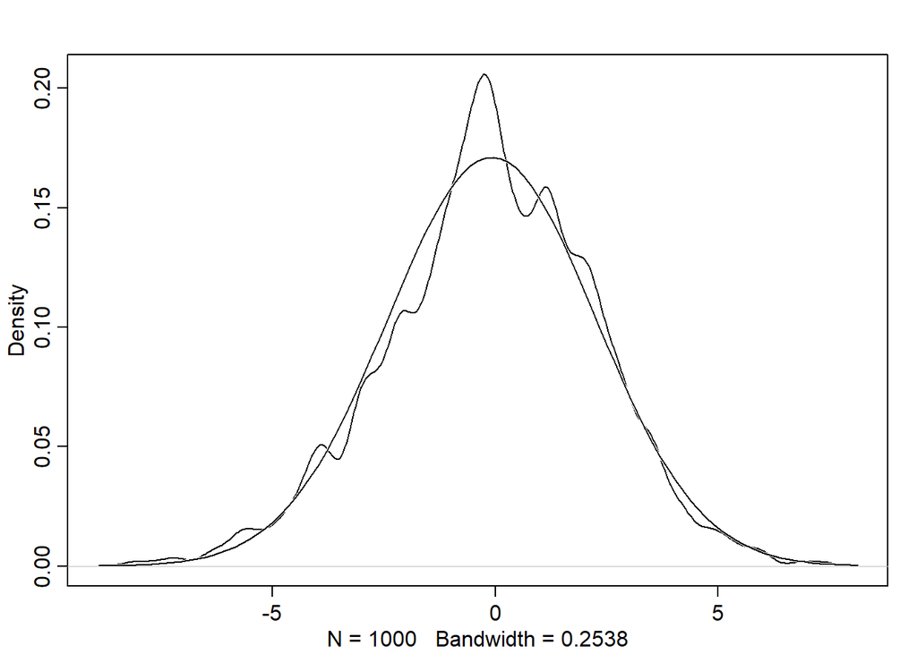

```r
#If you are unsure what these functions do, run the following:
#?runif()
#?replicate()
require(rethinking)
set.seed(100)
pos <- replicate( 1000 , sum( runif(16,-1,1) ))
dens(pos,norm.comp=T)
```

### 4.1.2. Normal by multiplication

McElreath now turns to another example to illustrate how to achieve a normal distribution through multiplication.

“Suppose the growth rate of an organism is influenced by a dozen loci, each with several alleles that code for more growth. Suppose also that all of these loci interact with one another, such that each increase growth by a percentage. This means that their effects multiply, rather than add.”

The line below illustrates how to model the multiplicative effects for a single sample

```r
# We can sample a random growth rate for this example with this line of code:
prod( 1 + runif(12,0,0.1) )
```

```
## [1] 1.531126
```

Now apply this to 10000 samples.

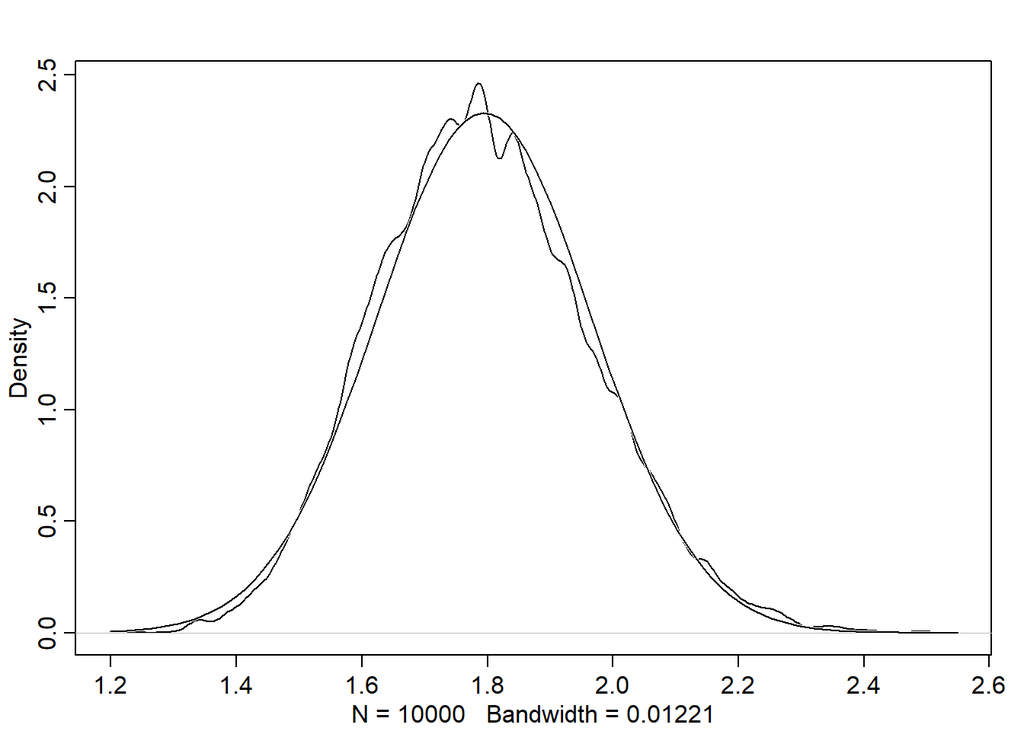

```r
set.seed(100)
growth <- replicate( 10000 , prod( 1 + runif(12,0,0.1) ) )
dens( growth , norm.comp=TRUE )
```

So we achieve a normal distribution, even in the case of multiplication. The caveat here is that this is only true when the multiplying factor is quite small, as these multiplicative effects tend towards the additive approximation for sufficiently small values.

Let’s compare larger and smaller deviates below to see how magnitude affects the additive approximation:

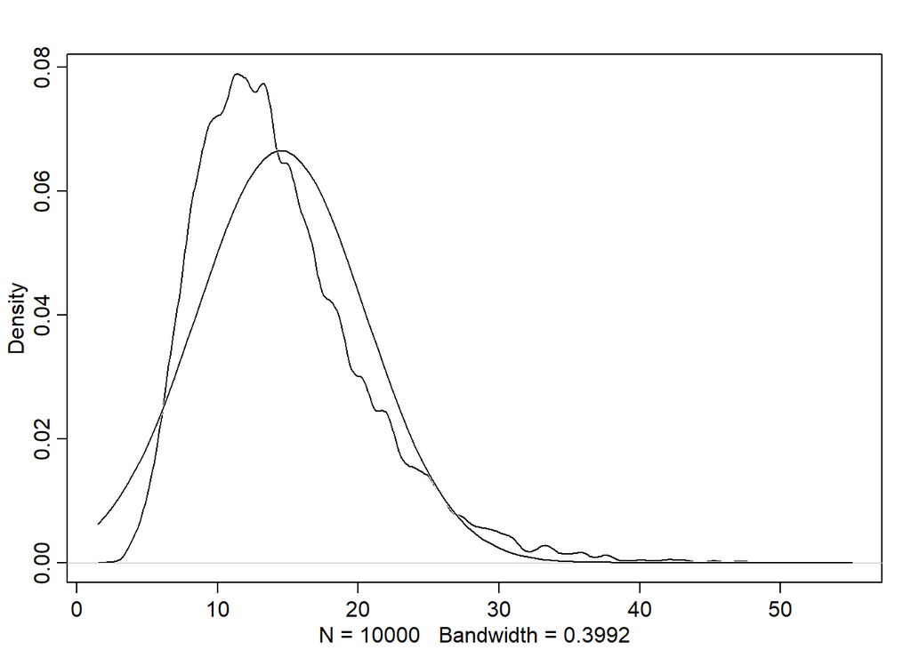

```r
set.seed(100)
big <- replicate( 10000 , prod( 1 + runif(12,0,0.5) ) )
dens(big,norm.comp=T)
```

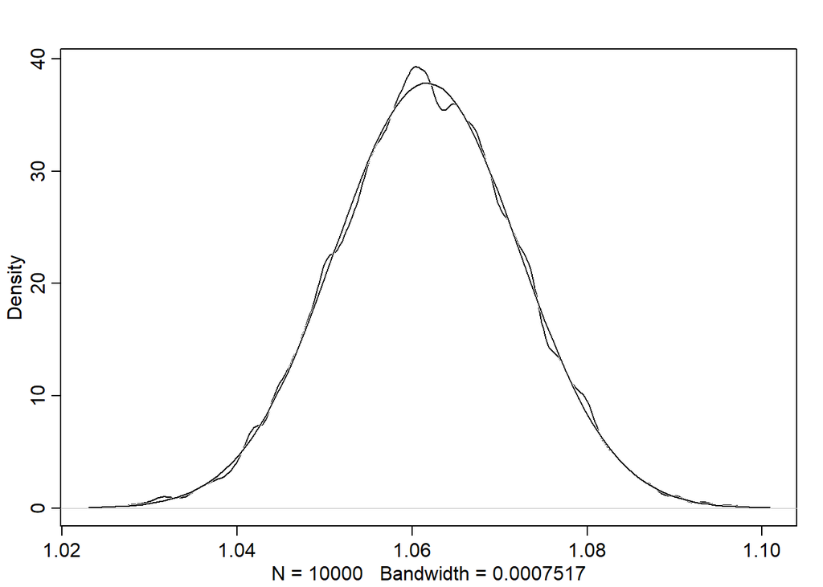

```r
small <- replicate( 10000 , prod( 1 + runif(12,0,0.01) ) )
dens(small,norm.comp=T)
```

### 4.1.3. Normal by log-multiplication

Even in the case of large multiplicative effect or deviates, Gaussian distributions can be achieved through log transformation:

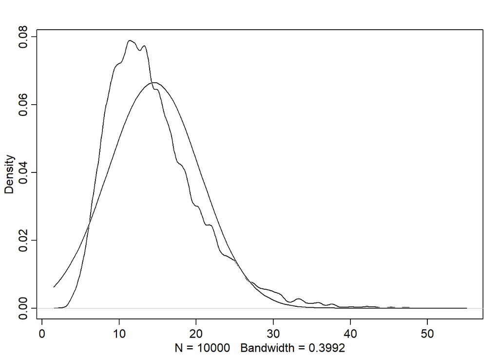

```r
#Before log transformation
set.seed(100)
big <- replicate( 10000 , prod( 1 + runif(12,0,0.5) ) )
dens(big,norm.comp=T)
```

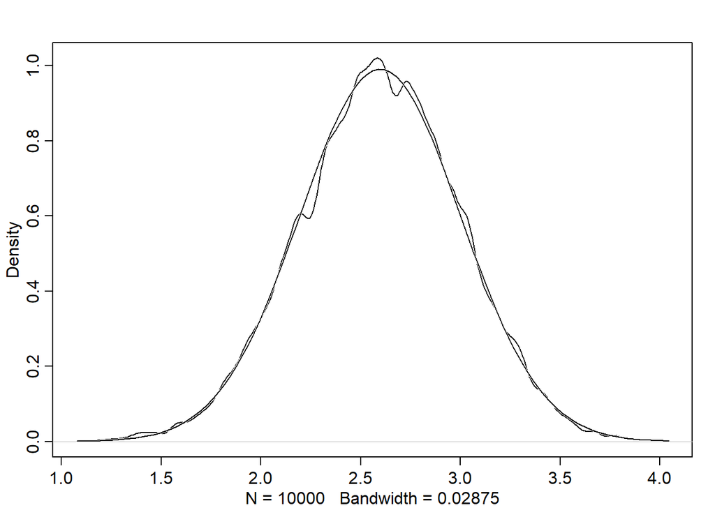

```r
#After log transformation
log.big <- replicate( 10000 , log(prod(1 + runif(12,0,0.5))) )
dens(log.big,norm.comp=T)
```

### 4.1.4. Using Gaussian distributions

The justifications for using the Gaussian distribution fall into two broad categories:

1. Ontological (related to the study of being)

Gaussian distributions are a widespread pattern, appearing again and again at different scales and in different domains. These distributions are widespread because at their heart, processes often add together fluctuations. Repeatedly adding finite fluctuations results in a distribution of sums that have shed all information about the underlying process, aside from mean and spread.

2. Epistemological (related to the study of knowledge)

The Gaussian represents a particular state of ignorance. When all we know or are willing to say about a distribution of measures (measures are continuous values on the real number line) is their mean and variance, then the Gaussian distribution arises as the most consistent with our assumptions. That is to say that the Gaussian distribution is the most natural expression of our state of ignorance, because if all we are willing to assume is that a measure has finite variance, the Gaussian distribution is the shape that can be realized in the largest number of ways and does not introduce any new assumptions. It is the least surprising and least informative assumption to make

## 4.2: A language for describing models

Here’s the approach to describing models, in abstract. There will be many examples later, but it is important to get the general recipe before seeing these.

1. First, we recognize a set of variables to work with. Some of these variables are observable. We call these data. Others are unobservable things like rates and averages. We call these parameters.
2. We define each variable either in terms of the other variables or in terms of a probability distribution.
3. The combination of variables and their probability distributions defines a joint generative model that can be used both to simulate hypothetical observations as well as analyze real ones

McElreath provides the following example:

$$\begin{equation}
y_{i} ∼ Normal(µ_{i}, σ)
\end{equation}$$
$$\begin{equation}
µ_{i} = βx_{i}
\end{equation}$$
$$\begin{equation}
β ∼ Normal(0, 10)
\end{equation}$$
$$\begin{equation}
σ ∼ Exponential(1)
\end{equation}$$
$$\begin{equation}
x_{i} ∼ Normal(0, 1)
\end{equation}$$

Examples further in the book provide more examples of using this language to describe models.

### 4.2.1. Redescribing the globe tossing model

## 4.3: Gaussian model of height

### 4.3.1. The data

The data contained in data(Howell1) are partial census data for the Dobe area !Kung San, compiled from interviews conducted by Nancy Howell in the late 1960s. For the non-anthropologists reading along, the !Kung San are the most famous foraging population of the twentieth century, largely because of detailed quantitative studies by people like Howell.

Load the data and place them into a convenient object with:

```r
library(rethinking)
data(Howell1)
d <- Howell1
```

What you have now is a data frame named simply d. I use the name d over and over again in this book to refer to the data frame we are working with at the moment. I keep its name short to save you typing. A data frame is a special kind of object in R. It is a table with named columns, corresponding to variables, and numbered rows, corresponding to individual cases. In this example, the cases are individuals. Inspect the structure of the data frame, the same way you can inspect the structure of any symbol in R

```r
str( d )
```

```
## 'data.frame':    544 obs. of  4 variables:
##  $ height: num  152 140 137 157 145 ...
##  $ weight: num  47.8 36.5 31.9 53 41.3 ...
##  $ age   : num  63 63 65 41 51 35 32 27 19 54 ...
##  $ male  : int  1 0 0 1 0 1 0 1 0 1 ...
```

We can also use rethinking’s precis summary function, which we’ll also use to summarize posterior distributions later on:

```r
precis( d )
```

```
##               mean         sd      5.5%     94.5%     histogram
## height 138.2635963 27.6024476 81.108550 165.73500 ▁▁▁▁▁▁▁▂▁▇▇▅▁
## weight  35.6106176 14.7191782  9.360721  54.50289 ▁▂▃▂▂▂▂▅▇▇▃▂▁
## age     29.3443934 20.7468882  1.000000  66.13500     ▇▅▅▃▅▂▂▁▁
## male     0.4724265  0.4996986  0.000000   1.00000    ▇▁▁▁▁▁▁▁▁▇
```

This data frame contains four columns. Each column has 544 entries, so there are 544 individuals in these data. Each individual has a recorded height (centimeters), weight (kilograms), age (years), and “maleness” (0 indicating female and 1 indicating male).

Read the symbol $ as extract, as in extract the column named height from the data frame d.

All we want for now are heights of adults in the sample. The reason to filter out nonadults for now is that height is strongly correlated with age, before adulthood. Later in the chapter, I’ll ask you to tackle the age problem. But for now, better to postpone it. You can filter the data frame down to individuals of age 18 or greater with:

```r
d2 <- d[ d$age >= 18 , ]
```

We’ll be working with the data frame d2 now. It should have 352 rows (individuals) in it.